# Métodos Computacionais para Análise de Risco

27 de junho de 2018

## Descrição dos dados

## Banco de dados

- O banco de dados escolhido do pacote CASdatasets é o canlifins.
- Este banco contem 14889 observações de contratos de anuidades de vida conjunta e de último sobrevivente em vigor de uma seguradora do Canadá no periodo de 29 de Dezembro de 1988 a 31 de dezembro de 1993.
- Há 5 variáveis que são:  
  Idade das mulheres no momento de contratação do plano.  
  Idade dos homens no momento de contratação do plano.  
  Tempo da morte das mulheres, zero se sobreviveu.  
  Tempo da morte dos homens, zero se sobreviveu.  
  Data do fim do contrato, se aplicável.

## Análise descritiva dos dados

## Análise descritiva: mulheres

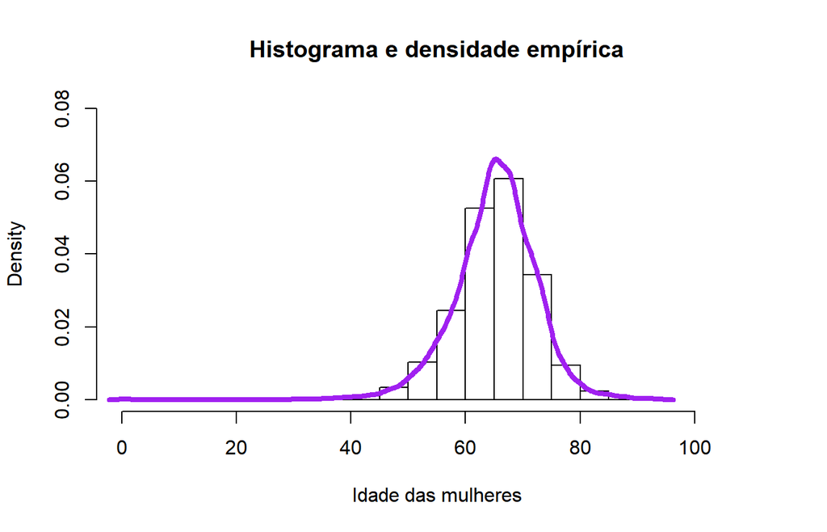

## Análise descritiva: mulheres

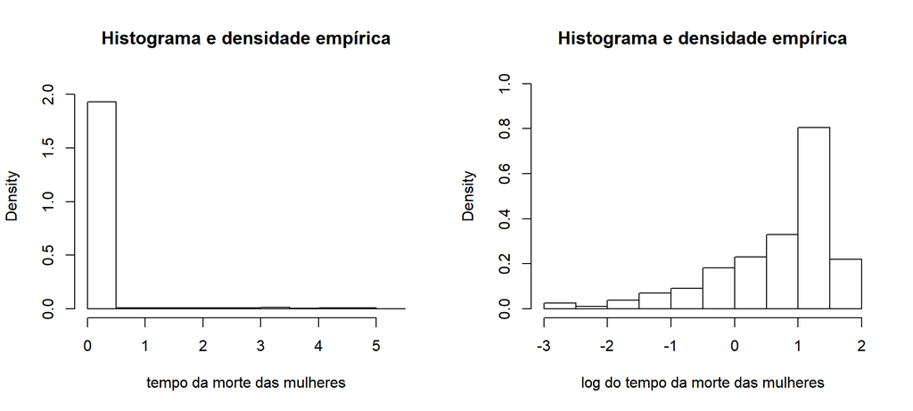

## Análise descritiva: homens

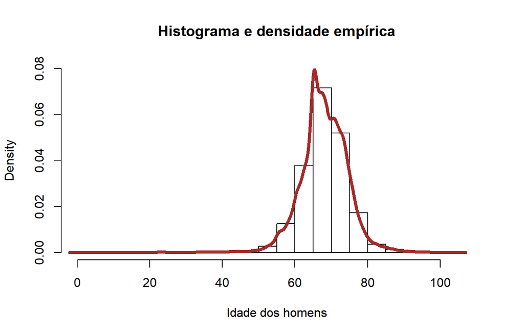

## Análise descritiva: homens

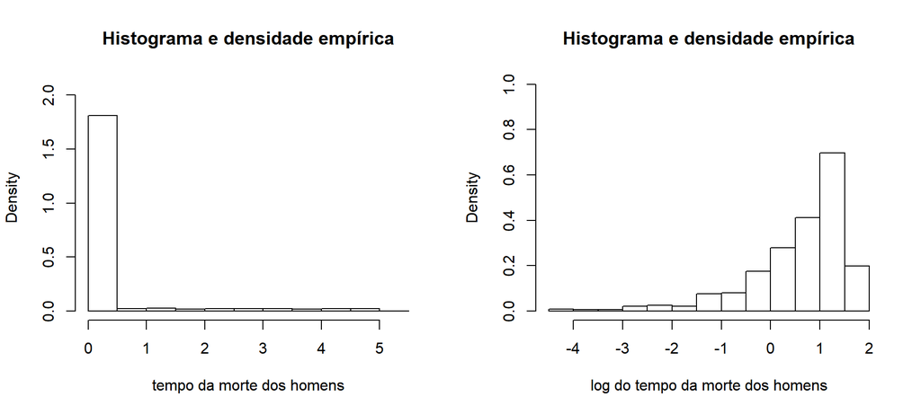

## Análise descritiva: tempo do contrato

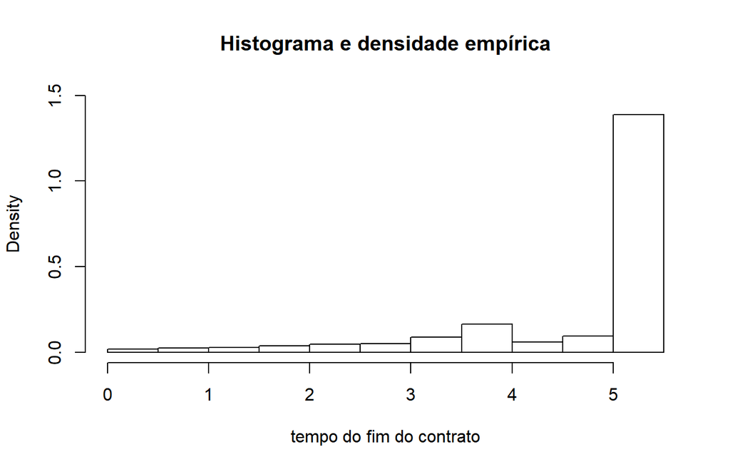

## Análise descritiva

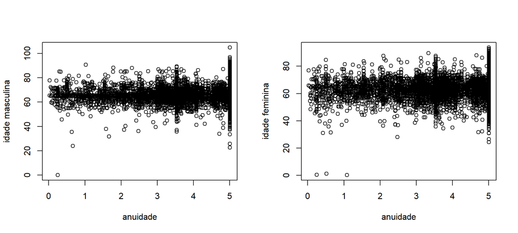

## Análise descritiva

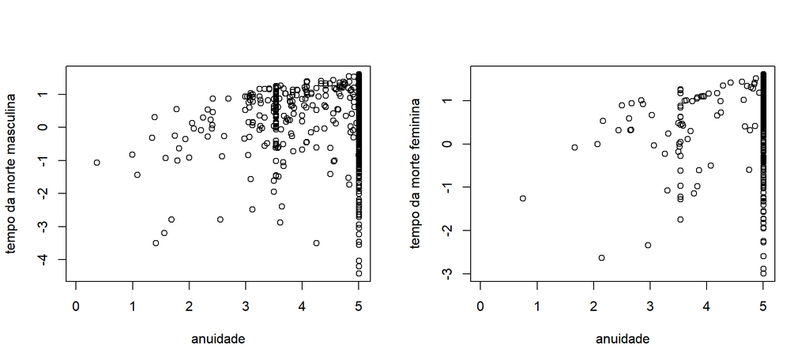

## Correlações

```
## contrato
##     0     1
##  4551 10338
```

| ageF | ageM | deathF | deathM |
| --- | --- | --- | --- |
| 0.2340534 | 0.2703914 | 0.0727865 | 0.1063584 |

## Modelo logístico

```
##
## Call:
## glm(formula = contrato ~ EntryAgeM + EntryAgeF + DeathTimeM +
##     DeathTimeF, family = binomial(link = "logit"))
##
## Deviance Residuals:
##     Min       1Q   Median       3Q      Max
## -2.9414  -1.2291   0.6754   0.8627   2.6319
##
## Coefficients:
##              Estimate Std. Error z value Pr(>|z|)
## (Intercept) -6.022046   0.226451 -26.593  < 2e-16 ***
## EntryAgeM    0.081659   0.004751  17.186  < 2e-16 ***
## EntryAgeF    0.019890   0.003939   5.050 4.42e-07 ***
## DeathTimeM   0.210113   0.028778   7.301 2.86e-13 ***
## DeathTimeF   0.227501   0.049415   4.604 4.15e-06 ***
## ---
## Signif. codes:  0 '***' 0.001 '**' 0.01 '*' 0.05 '.' 0.1 ' ' 1
##
## (Dispersion parameter for binomial family taken to be 1)
##
##     Null deviance: 18331  on 14888  degrees of freedom
## Residual deviance: 17060  on 14884  degrees of freedom
## AIC: 17070
##
## Number of Fisher Scoring iterations: 4
```

## Análise do modelo

O acréscimo de uma unidade na idade de entrada do homem ocasiona um aumento de 8% na chance, já com o mesmo acréscimo na idade da mulher o aumento da chance é de 2%. Já para as mortes, para cada unidade acrescida no numero de mortes dos homens e das mulheres há um amento de 23% e 25% respectivamente.

O aumento na chance de cada variável é analisado sempre considerando as demais variáveis contantes.

| beta.1 | beta.2 | beta.3 | beta.4 |
| --- | --- | --- | --- |
| 1.085086 | 1.020089 | 1.233818 | 1.255459 |